# STAT230 Work Team Project

Work Team 7: Evan, Becca, Laith

## Introduction & Motivation

We are interested in how we can attempt to predict the profitability of farms by different farming practices. Specifically we are curious about sustainable agriculture decisions and decisions about crop types. From a conservationist perspective, it is important that sustainable choices are economically viable for farmers. https://www.nass.usda.gov/AgCensus/

Our data is sourced from the United States Census of Agriculture, between the years 2009 and 2017, along with county demographic information from Wikipedia, sourced from the U.S Census. The data is collected by county, often summing the a variable across all operations in a given county. This limits our specificity, but we are still able to estimate what is typical for farms across the county by looking at averages for each county.

Our response variable in reported farm income, and we are planning to predict it with a number of variables (population density, farm acres, bee colonies, grazing rotation, fertilizer use).

Grazing rotation refers to the number of farming operations in a county that reported using either crop cycling or alternating patterns of grazing to minimize impact. Farm acres and bee colonies are counts that are summed across all farms within a state. Fertilizer use is the total dollar amount spent on fertilizers in that year by all farming operations in a given county. Population density was estimated based on county sizes and populations based on the U.S census via Wikipedia. We feel that this combination of predictors is appropriate because it examines many dimensions of farming practices. It includes information about context of the farming (population density, farm size) as well as the types of methods of sustainable or unsustainable practices carried out in each of these counties. It is valuable to understand how economically viable sustainable farming is in the short term in order to access if further supportive measures should be taken in order to ensure both sufficient food production, as well as producing that food in ways that will limit harm to the Earth.

## Dataset & Wrangling

The initial combining, and wrangling of this large data set can be found at https://github.com/evanmacarthur/Stat230Proj1. The data wrangling was then perfected as shown in appendix 1

## Exploratory Data Analysis (EDA)

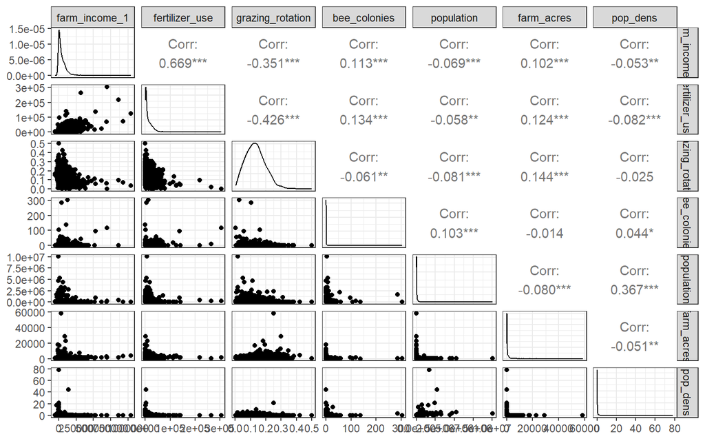

> There are significant correlations with all variables, but lots of these associations do not look linear or normal. Transforming the data may help improve these relationships.

> Starting with the response variable, we see that the mean is higher than the median suggesting a right skewed relationship. We used a log transformation.

We log-transposed+transformed farm income such that it better matched a normal distribution.

> Looks much improved, the mean is 11.4, and median is 11.319, and the histogram still is not ideal, but better. The IQR = 0.699, likely due to the sampling methods, which only include farms that carry out above $1200 of business annually. It seems like this may introduce a this sort of sharp drop-off in log(farm income)

> This improved linearity slightly, but still questionable, lets look at predictors.

> This does not look great, heavily skewed distribution and it is difficult to assess the scatterplot, the mean is 12600, the median is 6182, and the IQR is 16406. Will try transforming.

> This one is also not great, scatterplot not very useful, the histogram is right skewed, the mean is 0.29922 and median is 0.064434, and the IQR is 0.14181.

> This one still does not look great after transforming, but it probably helped. The graph is still right skewed, but not as strongly, with a mean of 0.16477 and a median of 0.062443, and IQR of 0.12962, and the relationship based on the scatter plot is not very useful.

> Once again, unhelpful scatterplot, right skewed distribution, mean of 291893, median of 179306 and IQR of 282196

> This transformation improved it somewhat, the histogram is less right skewed, but the relationship does not look very linear based on the scatter plot, the mean is 20.833 and the median is 16.353, and the IQR is 10.446

> Very strongly right skewed histogram, scatterplot is not useful for assessing linearity, the mean is 1.1837, the median is 0.16083, and the IQR is 0.35789

> This distribution looks pretty good. Relatively normal histogram, and the scatter plot shows a relatively linear relationship. mean is 0.13218, median is 0.12806 and IQR is 0.08744

> After we have tried to improve all of the response variables, lets take a look at the ggpairs again

> These generally look much better, we still have a lot of 0 values in the population density, but they are real, so the data is not actually normally distributed. The scatter plots generally look much more linear than before transforming the variables, and the correlations are similar to before transforming. Bee colonies is no longer correlated though I removed missing values to make my following tests and operations easier.

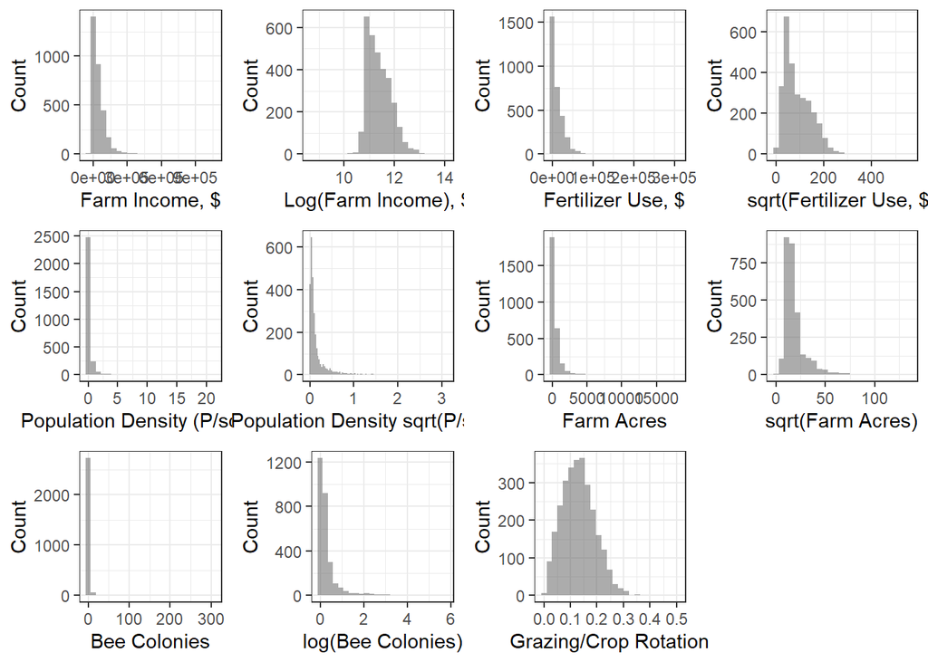

# Model selection

adjr2

cp

bic

rss

farm_acres_2

pop_dens_2

grazing_rotation

fertilizer_use_2

bee_colonies_2

1 ( 1 )

0.521

100.154

-2053.1

283.48

2 ( 1 )

0.530

44.510

-2101.5

277.86

3 ( 1 )

0.536

5.694

-2134.1

273.89

4 ( 1 )

0.537

4.283

-2129.6

273.56

5 ( 1 )

0.537

6.000

-2121.9

273.53

## Model comparison - conditions

> As shown in the appendix, the residuals vs fitted plot, QQ plot, and histogram of the residuals of both models are practically identical and will not serve as a point of difference. The linearity condition is mostly met, as there is mostly symmetry over the line residual=0 on the residuals vs fitted values plot, and there does not seem to be major bending or curving of points. However, there is a noticeable lack of symmetry around a fitted value of 11, and there overall seems to be more variance for positive residual values, which is concerning. The equal variance condition is questionable as there is lower residual variance for higher fitted values. The normality condition is also questionable. Although the QQ-plot is mostly a straight line with mostly no bending, there does seem to be a very large and bent tail at the high end. Furthermore, the histogram of the residuals, while it is unimodal and centered close to 0, is right skewed. We assumed that data values were collected independently. Finally, there appear to be several unusual points in both models.

> We next confirmed that our variable transformations helped improve model conditions. As displayed in the appendix, there are many more extreme outliers in the untransformed model, with many very high fitted values that would exert undue influence over our model. As seen in the histogram, the data is highly right skewed. Based on these results, we felt confident that our transformations improved model conditions, even though they did not fully remove condition concerns, and we proceeded with the transformed model.

## Model comparison - outliers and influential points

```
## [1] 2813    6
```

```
## [1] 0.0035549
```

```
## [1] 0.0053324
```

```
## [1] 71
```

## Model comparison - multicollinearity

> VIF tables

x

<table> <thead> <tr> <th style="text-align:left;"> </th> <th style="text-align:right;"> x </th> </tr> </thead> <tbody> <tr> <td style="text-align:left;"> pop_dens_2 </td> <td style="text-align:right;"> 1.1427 </td> </tr> <tr> <td style="text-align:left;"> grazing_rotation </td> <td style="text-align:right;"> 1.4723 </td> </tr> <tr> <td style="text-align:left;"> fertilizer_use_2 </td> <td style="text-align:right;"> 1.6138 </td> </tr> <tr> <td style="text-align:left;"> farm_acres_2 </td> <td style="text-align:right;"> 1.2880 </td> </tr> </tbody> </table>

x

<table> <thead> <tr> <th style="text-align:left;"> </th> <th style="text-align:right;"> x </th> </tr> </thead> <tbody> <tr> <td style="text-align:left;"> farm_acres_2 </td> <td style="text-align:right;"> 1.2984 </td> </tr> <tr> <td style="text-align:left;"> pop_dens_2 </td> <td style="text-align:right;"> 1.1975 </td> </tr> <tr> <td style="text-align:left;"> grazing_rotation </td> <td style="text-align:right;"> 1.4745 </td> </tr> <tr> <td style="text-align:left;"> fertilizer_use_2 </td> <td style="text-align:right;"> 1.6378 </td> </tr> <tr> <td style="text-align:left;"> bee_colonies_2 </td> <td style="text-align:right;"> 1.0786 </td> </tr> </tbody> </table>

> We next checked for multicollinearity in both models by analyzing correlation plots and VIF scores. All VIF scores for both models were below 2, indicating that multicollinearity is not a concern for either model. The inclusion of bee_colonies_2 in fmB has little impact on VIF scores. The correlation matrix for the bee_colonies_2 pairs isn’t too concerning with correlation coefficients of 0.23 or lower (see appendix). This further indicates that including bee_colonies_2 does not increase multicollinearity.

## Model comparison - Added Variable Plot

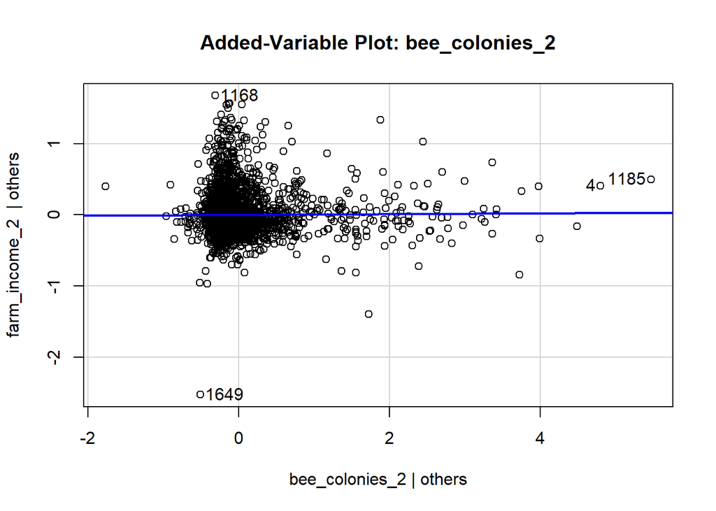

## Model comparison - Nested F-Test

$H_0: \beta_{bee-colonies} = 0$ $H_A: \beta_{bee-colonies} \neq 0$

> We performed a nested F test on the two models, with the above null and alternative hypotheses. The test resulted in a p-value of 0.59, so we fail to reject the null hypothesis and do not have enough evidence to conclude the that the predictor bee_colonies_2 is significant after controlling for other predictor effects.

## Bootstrapping

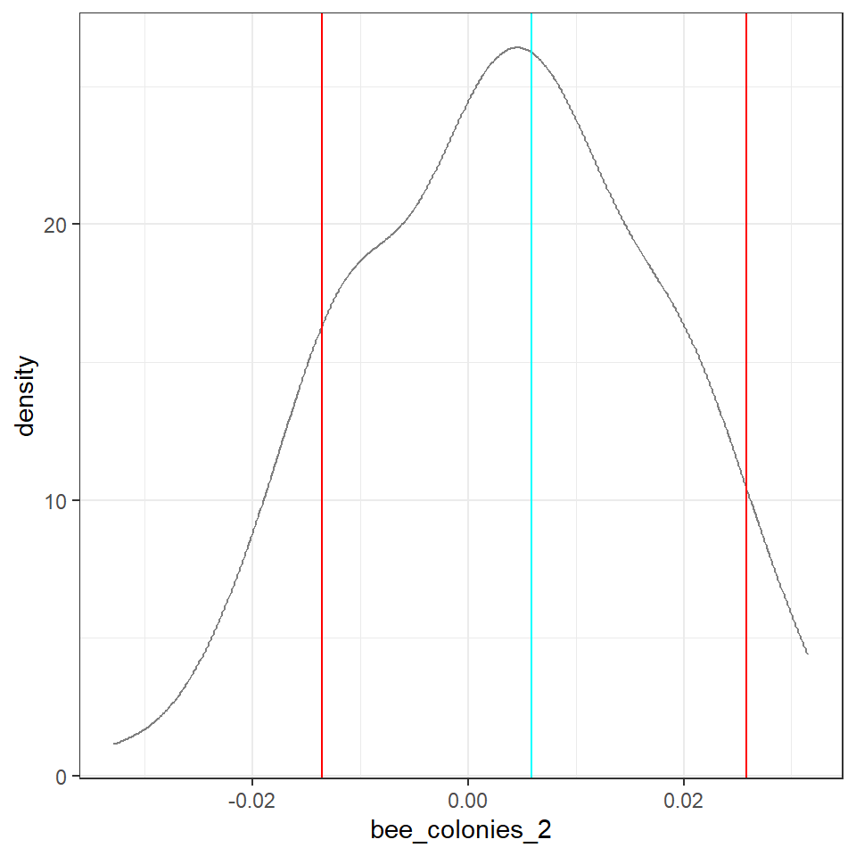

## Final evaluation of 4 and 5 term models

> We conclude that fmA, the four term model is preferable to fmB, the five term model that includes bee colonies as a predictor. As described above, fmA and fmB have very similar deviations from model conditions. However, fmB has about 100 more points with high leverage than fmA, indicating that fmB has more potential to make inaccurate predictions than fmA.

> After controlling for the effects of the other four predictors, bee colonies has an insignificant effect on farm income, as indicated by a nested f test and individual coefficient t stat with p values of 0.59. We double checked this result with a bootstrap test since our model did not fit conditions, but still found that the effects of bee colonies on farm income were insignificant.

> Furthermore, as we saw in our initial model selection process, fmA is a stronger model than fmB. Both models have an adjusted $R^2$ of 0.537, and fmA has lower AIC and Cp scores than fmB. Overall, we found no reasons why fmB is preferable and many reasons why fmA is preferable. We will therefore proceed with analyzing fmA.

## Outlier removal

> One outlier, at index 1649, stands out in our equal variance plot and has the largest standard residual value in fmA. We tried removing it and reassessing conditions and model fit. See the appendix for our specific model results for this new model, fmA3. Removing this outlier decreased residual variance at the outlier’s fitted value and taking out such an extreme value improved data normality. However, both equal variance and normality are still very questionable.

> Removing this outlier did slightly decrease the significance of pop_dens_2 (p = 1.1e-13 compared to 5.5e-14 with the outlier) and farm_acres_2 (p = 0.072 compared to 0.065 with the outlier). However, removing the outlier increased $R^2$ by 0.5%, from 0.537 to 0.542. Given that taking out this outlier improved model conditions and increased model strength slightly, and since the impacts on model significance were small and less important than improvement to model conditions, we decided that it made sense to leave the outlier out of our model.

## Interactions

> Finally, we decided to test some interactions in our model. We specifically tested all interactions involving population density, since we thought that the population density of a county could modulate the effects of farm size and farming practices on farm income. For example, more populous counties might have more access to resources that would help them profitably employ fertilizer and grazing rotation practices.

> See the appendix for specific model results for this model, fmC. We first checked the conditions of our model with these three interaction terms. Equal variance, normality, and linearity looked very similar to our model without interactions. Looking at model significance, we found that all three interactions were significant or close to significant: p=0.0561 for pop_dens_2:grazing_rotation; p=0.0274 for pop_dens_2:fertilizer_use_2; p=0.0199 for pop_dens_2:farm_acres_2. However, adding these interaction terms barely increased the overall strength of our model: $R^2$ adjusted changed from 0.542 to 0.543. Although these interactions are interesting and fairly significant, they are not strong predictors of farm income and do not improve model conditions. We decided not to include them in our final model in order to simplify our model. This allowed us to interpret the effects of individual predictors on farm income.

## Appendices

### Appendix 1: Data Wrangling

```r
df0 <- read_csv("gooddata.csv")
df0 <- df0 |>
  clean_names()
df0 <- df0 |>
  rename("num_operations" = farm_operations_number_of_operations)

df <- df0 |>
  dplyr::select(c(farm_income_1, num_operations, fertilizer_use, grazing_rotation, bee_colonies, population, county_acreage_2000, farm_acres))

df1 <- df |>
  mutate(pop_dens = population/county_acreage_2000)

df1 <- df1 |>
  mutate(fertilizer_use = fertilizer_use/num_operations) |>
  mutate(grazing_rotation = grazing_rotation/num_operations) |>
  mutate(bee_colonies = bee_colonies/num_operations) |>
  mutate(farm_acres = farm_acres/num_operations)

df1 <- df1 |>
  dplyr::select(!c(num_operations, county_acreage_2000))

df1 <- df1 |>
  filter(!is.infinite(pop_dens))
```

### Appendix 2. Plots of observed vs theoretical values, and Q-Q plots for the initial three models

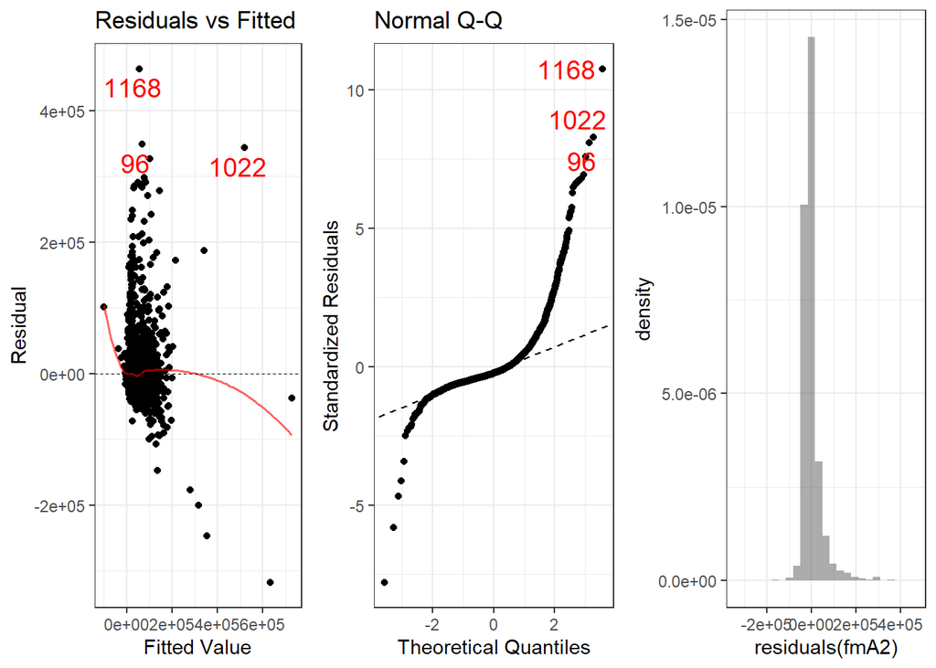

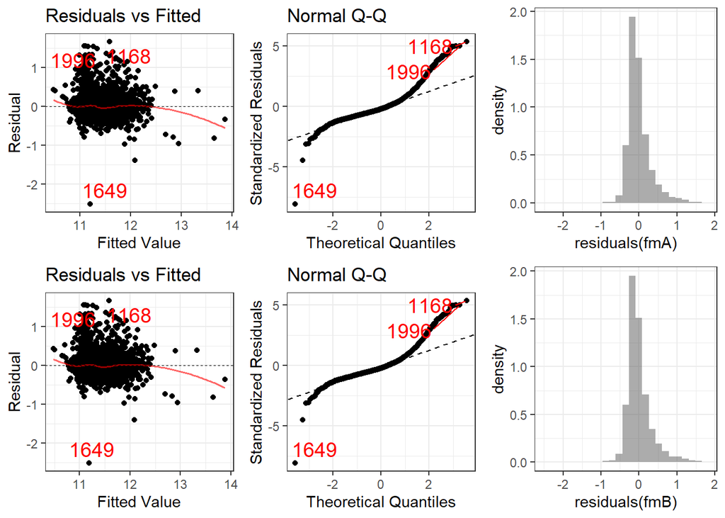

### Appendix 3: variable transformation scatter plots

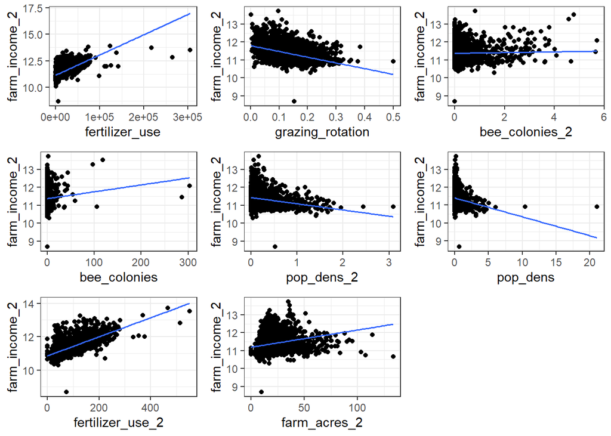

### Appendix 4: Numeric summaries of transformed variables

Summary of Transformed Farm Acres

|  | min | Q1 | median | Q3 | max | mean | sd | n | missing |
| --- | --- | --- | --- | --- | --- | --- | --- | --- | --- |
|  | 0 | 12.398 | 15.847 | 21.419 | 133.78 | 19.312 | 11.976 | 2813 | 0 |

Summary of Farm Acres

|  | min | Q1 | median | Q3 | max | mean | sd | n | missing |
| --- | --- | --- | --- | --- | --- | --- | --- | --- | --- |
|  | 0 | 153.72 | 251.13 | 458.79 | 17896 | 516.31 | 932.61 | 2813 | 0 |

Summary of Transformed Population Density

|  | min | Q1 | median | Q3 | max | mean | sd | n | missing |
| --- | --- | --- | --- | --- | --- | --- | --- | --- | --- |
|  | 0.00038 | 0.02955 | 0.06958 | 0.16599 | 3.0948 | 0.16445 | 0.26464 | 2813 | 0 |

Summary of Population Density

|  | min | Q1 | median | Q3 | max | mean | sd | n | missing |
| --- | --- | --- | --- | --- | --- | --- | --- | --- | --- |
|  | 0.00038 | 0.02999 | 0.07206 | 0.18056 | 21.082 | 0.2402 | 0.66928 | 2813 | 0 |

Summary of Transformed Fertilizer Use

|  | min | Q1 | median | Q3 | max | mean | sd | n | missing |
| --- | --- | --- | --- | --- | --- | --- | --- | --- | --- |
|  | 0 | 45.296 | 76.297 | 131.4 | 552.37 | 91.652 | 58.097 | 2813 | 0 |

Summary of Fertilizer Use

|  | min | Q1 | median | Q3 | max | mean | sd | n | missing |
| --- | --- | --- | --- | --- | --- | --- | --- | --- | --- |
|  | 0 | 2105.3 | 6182 | 18511 | 305114 | 12600 | 16789 | 3069 | 6 |

Summary of Transformed Farm Income

|  | min | Q1 | median | Q3 | max | mean | sd | n | missing |
| --- | --- | --- | --- | --- | --- | --- | --- | --- | --- |
|  | 8.6733 | 11.013 | 11.319 | 11.712 | 13.908 | 11.4 | 0.48011 | 3075 | 0 |

Summary of Farm Income

|  | min | Q1 | median | Q3 | max | mean | sd | n | missing |
| --- | --- | --- | --- | --- | --- | --- | --- | --- | --- |
|  | -55150 | 5494.5 | 27177 | 66913 | 1041275 | 46857 | 67968 | 3076 | 0 |

Summary of Grazing/Crop Rotation

|  | min | Q1 | median | Q3 | max | mean | sd | n | missing |
| --- | --- | --- | --- | --- | --- | --- | --- | --- | --- |
|  | 0.00253 | 0.08698 | 0.12854 | 0.17155 | 0.5 | 0.13179 | 0.06138 | 2813 | 0 |

### Appendix 5: ggpairs w/ just Farm Income Transformed

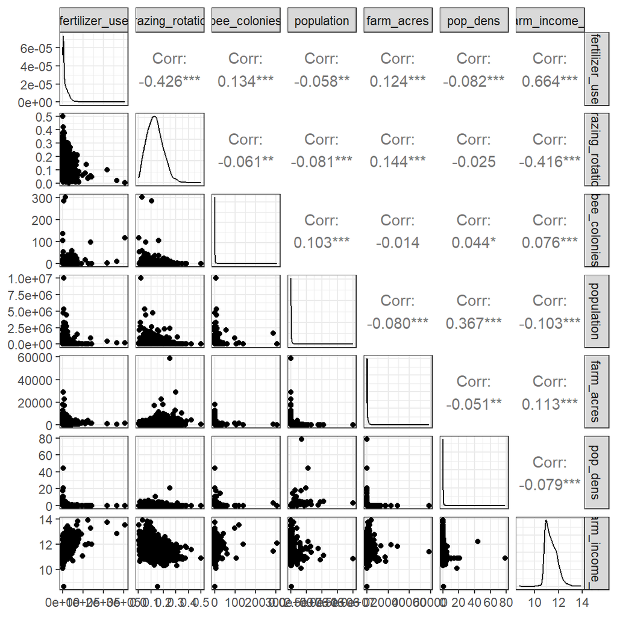

### Appendix 6: Variable Transformations

```r
df2 <- df1 |>
  mutate(farm_income_2 = log(farm_income_1+55152))
df2 <- df2 |>
  filter(farm_income_2 > 5)
df3 <- df2 |>
  mutate(fertilizer_use_2 = sqrt(fertilizer_use))
df3 <- df3 |>
  mutate(pop_dens_2 = log(pop_dens+1))
df3 <- df3 |>
  filter(!is.infinite(pop_dens_2))
df3 <- df3 |>
  mutate(farm_acres_2 = sqrt(farm_acres))
df3 <- df3 |>
  mutate(bee_colonies_2 = log(bee_colonies+1))
df4 <- df3 |>
  dplyr::select(c(farm_income_2, farm_acres_2, pop_dens_2, grazing_rotation, fertilizer_use_2, bee_colonies_2))
df4 <- na.omit(df4)
df3<-na.omit(df3)
```

### Appendix 7: ggpairs of Transformed Variables

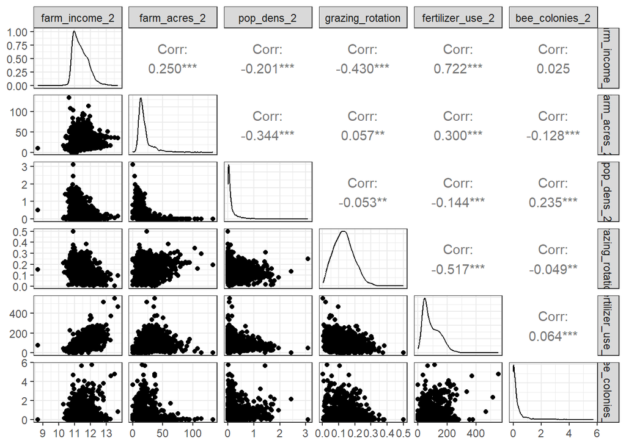

### Appendix 8: Comparison of Farm Income transformation

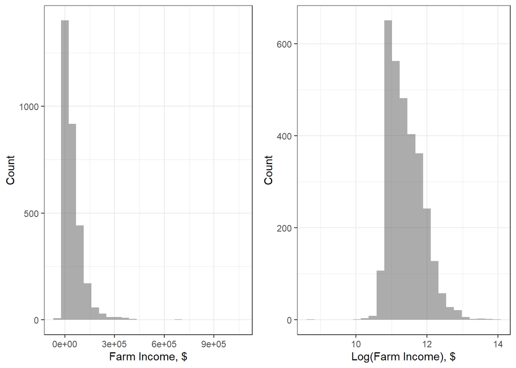

# Becca Appendix: Model selection and interpretation

## Model selection

Stepwise regression:

Backwards elimination:

| Step | Df | Deviance | Resid. Df | Resid. Dev | AIC |
| --- | --- | --- | --- | --- | --- |
|  | NA | NA | 2807 | 273.53 | -6544.0 |
| - bee_colonies_2 | 1 | 0.027553 | 2808 | 273.55 | -6545.7 |

## Model comparison - conditions

fmA conditions:

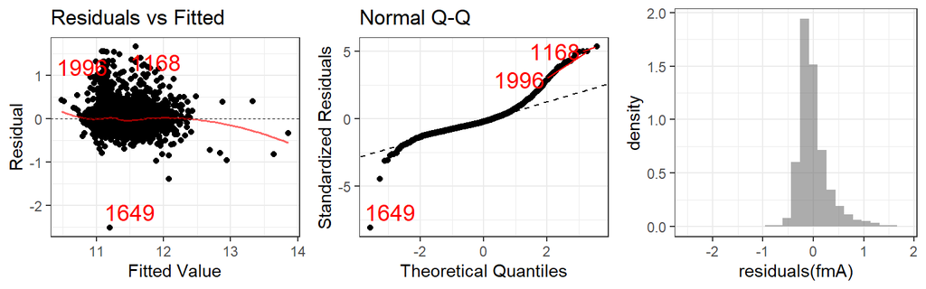

fmB conditions:

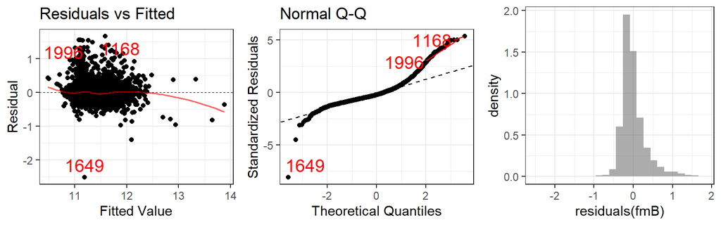

Untransformed fmA conditions:

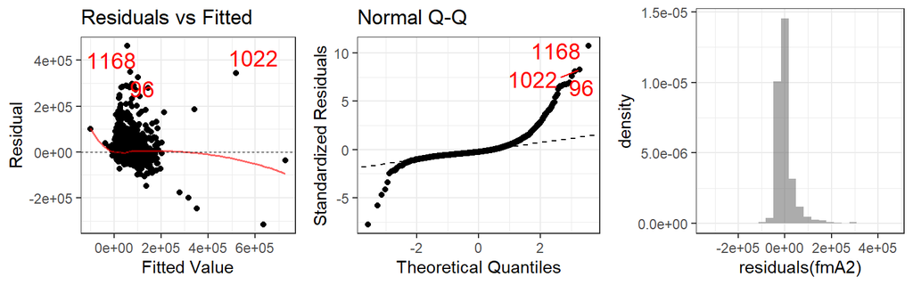

## Model comparison - outliers and influential points

fmA plots:

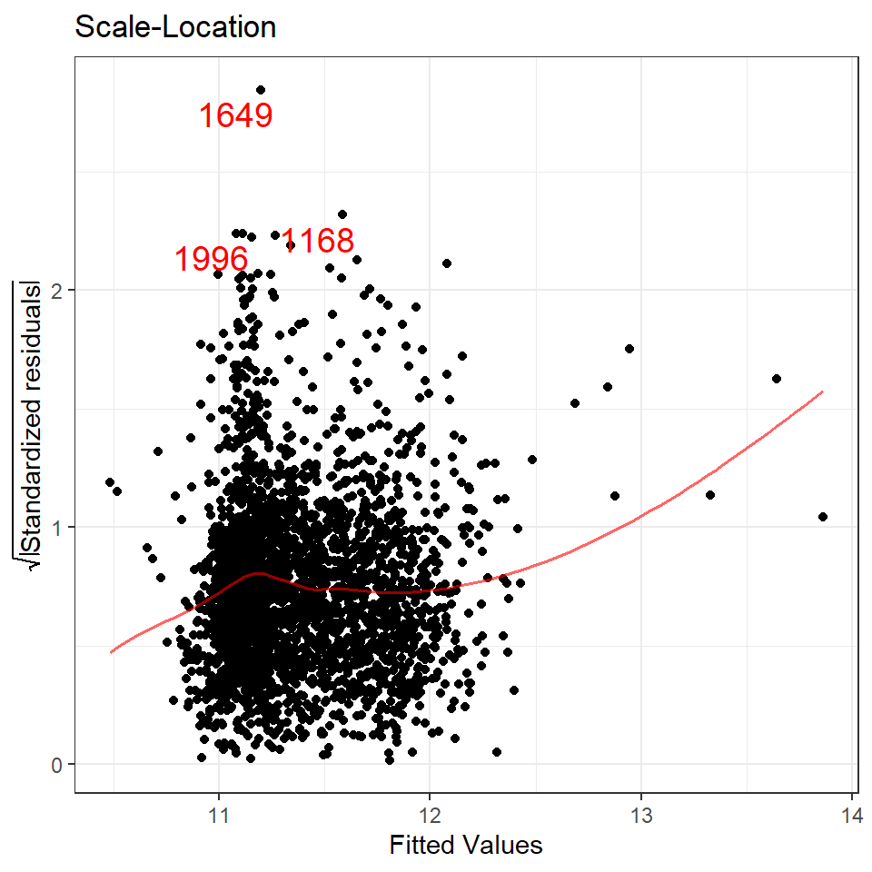

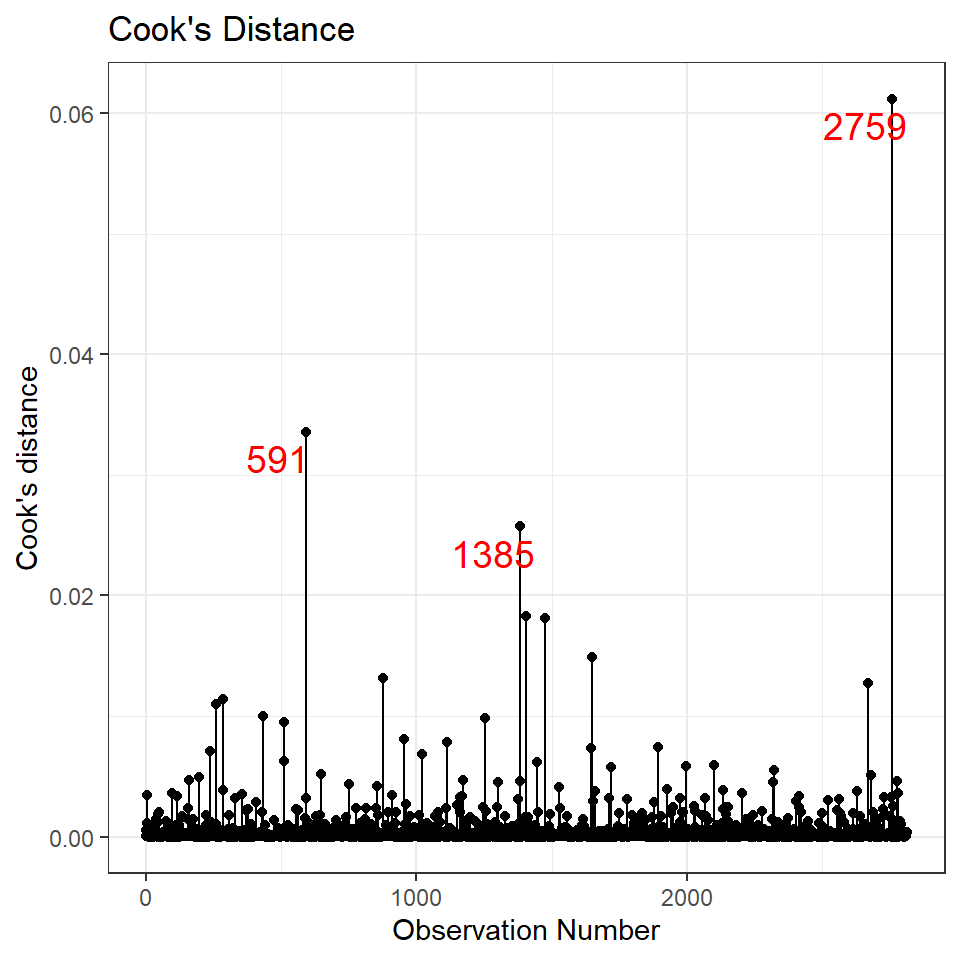

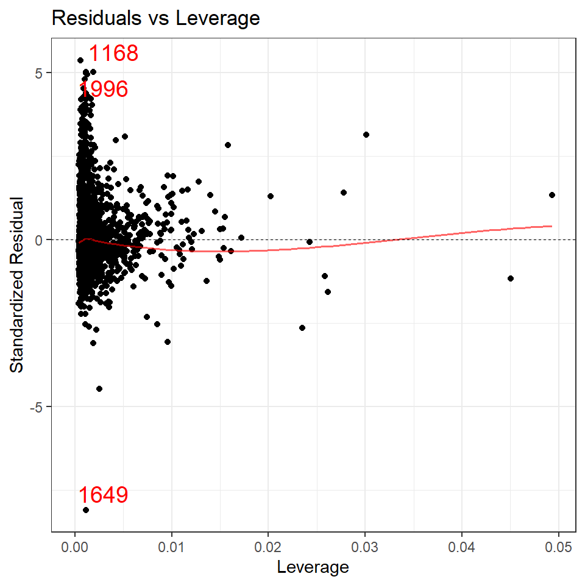

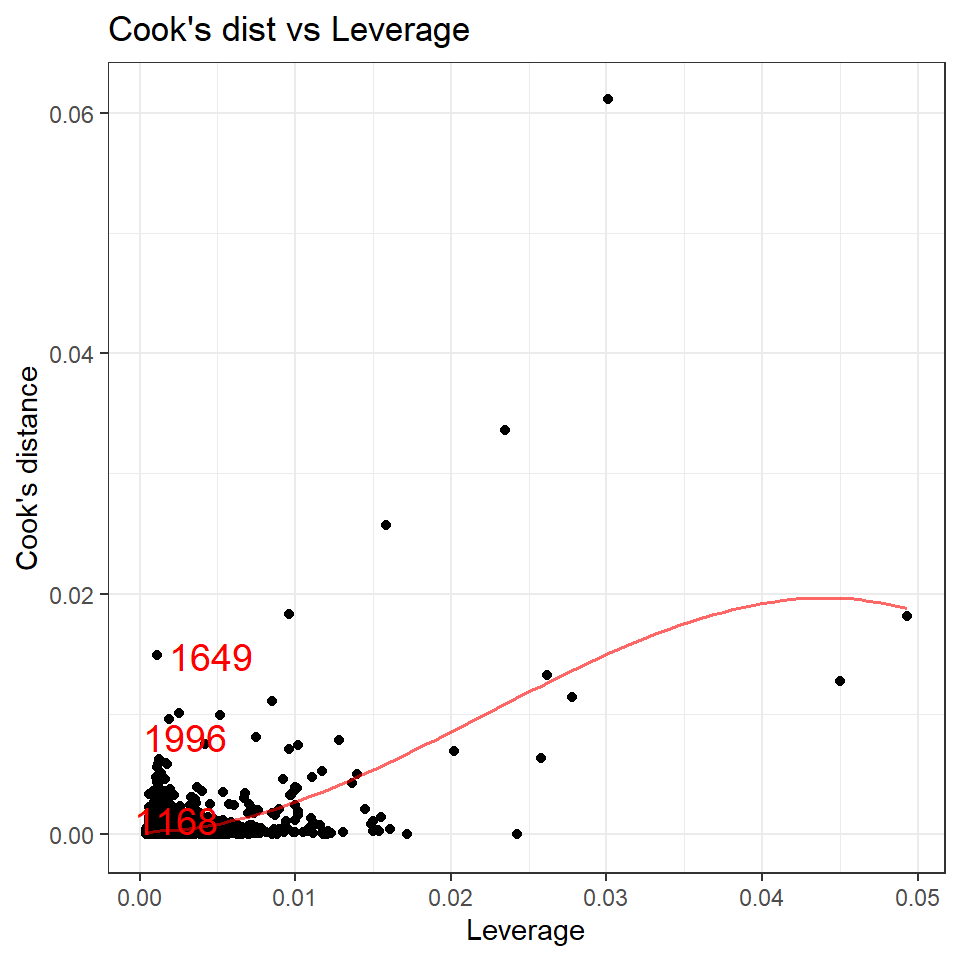

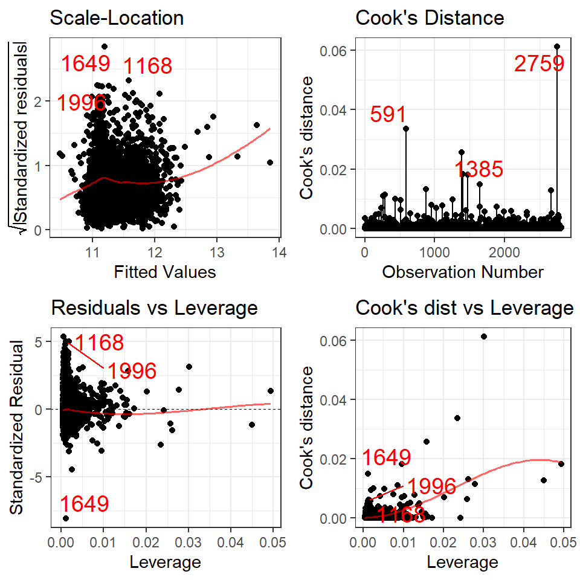

fmB plots:

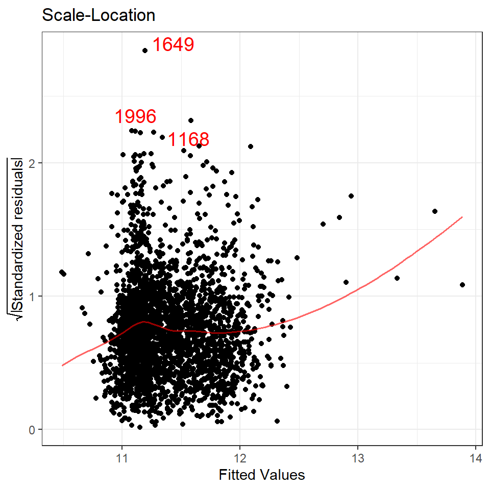

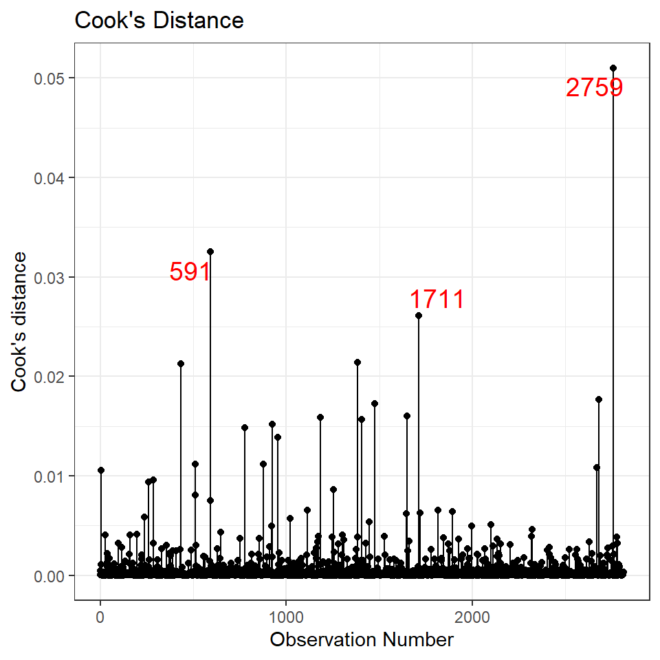

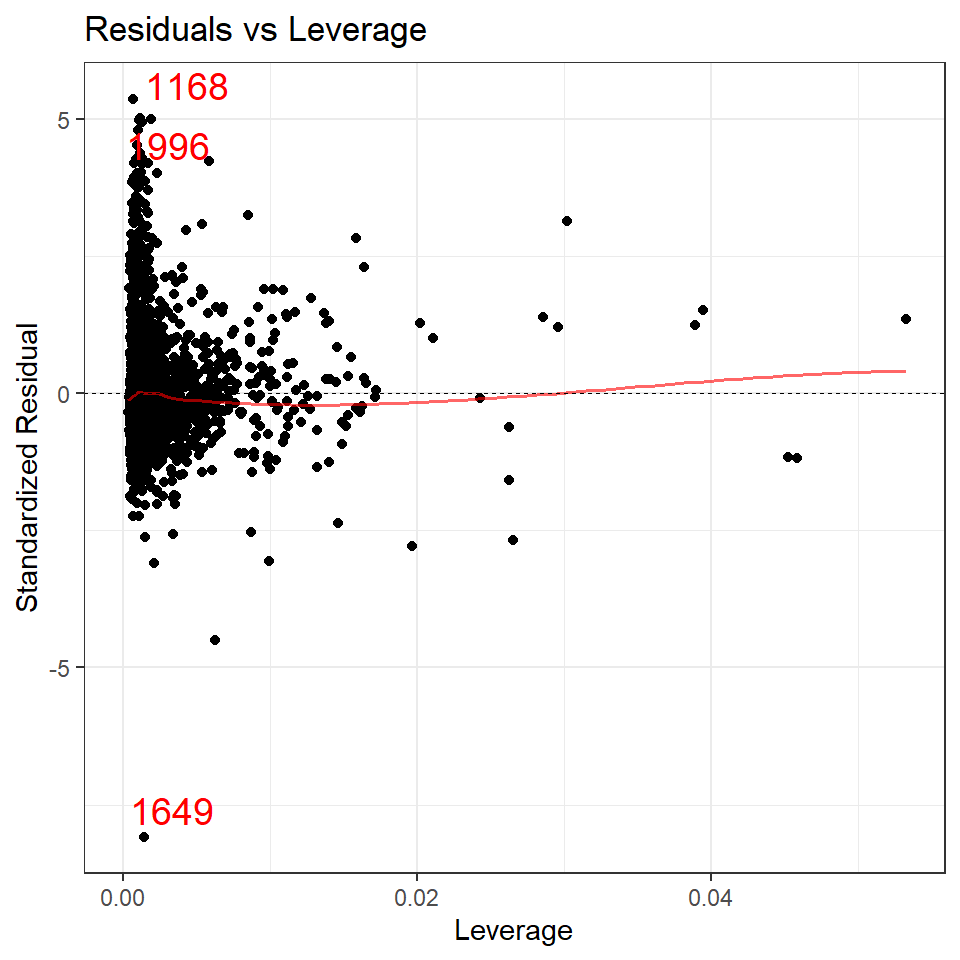

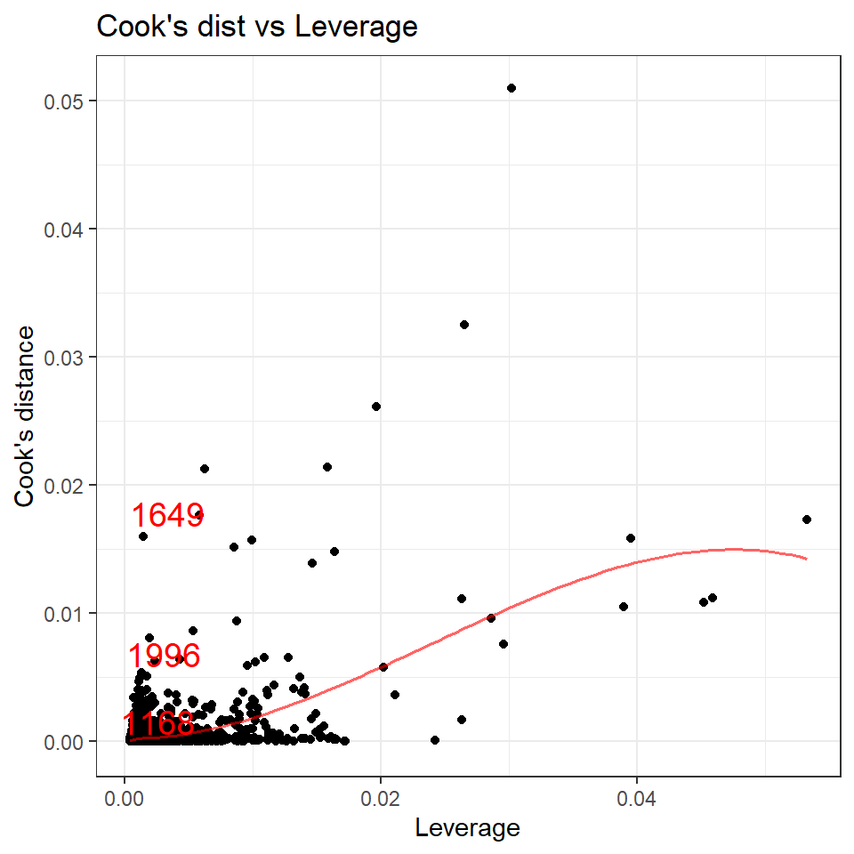

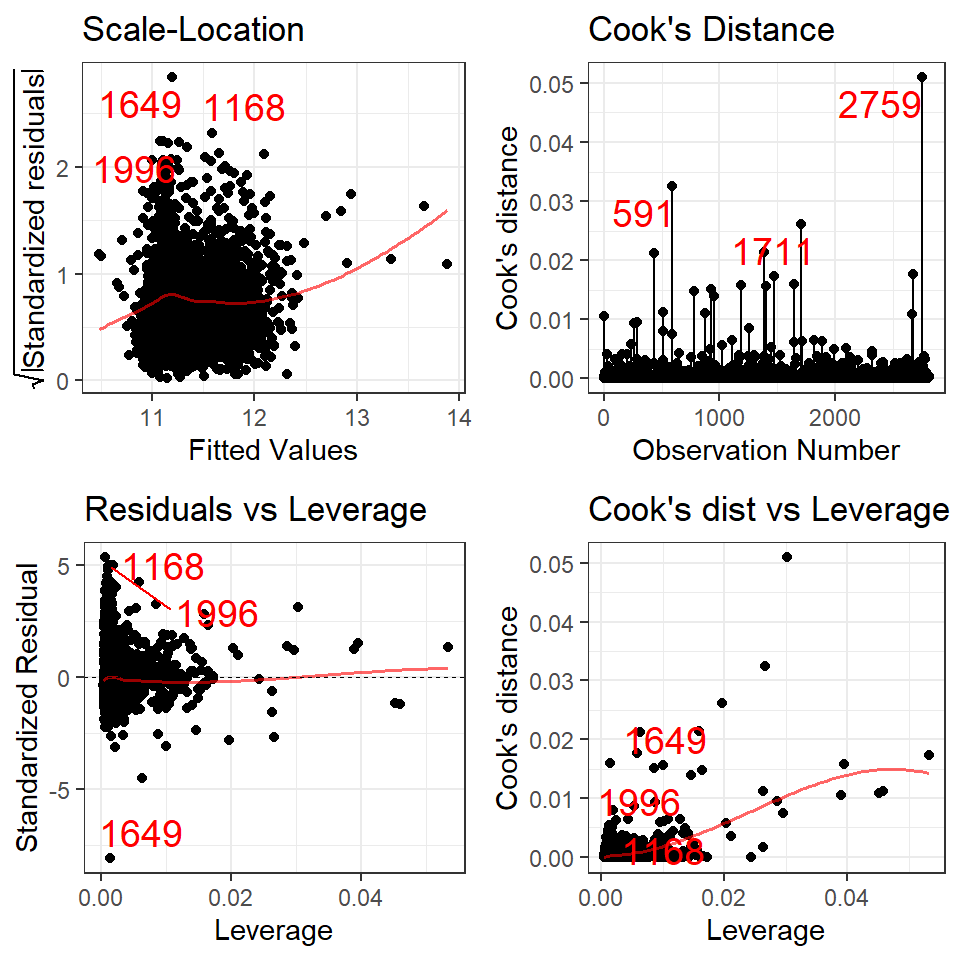

## Model comparison - multicollinearity

Correlation matrix and plot matrix for all relevant variables:

```
##                  farm_income_2 farm_acres_2 pop_dens_2 grazing_rotation
## farm_income_2         1.000000     0.250045  -0.200636        -0.430220
## farm_acres_2          0.250045     1.000000  -0.343740         0.056543
## pop_dens_2           -0.200636    -0.343740   1.000000        -0.052888
## grazing_rotation     -0.430220     0.056543  -0.052888         1.000000
## fertilizer_use_2      0.721624     0.299724  -0.144407        -0.517474
## bee_colonies_2        0.024889    -0.128397   0.235198        -0.049328
##                  fertilizer_use_2 bee_colonies_2
## farm_income_2            0.721624       0.024889
## farm_acres_2             0.299724      -0.128397
## pop_dens_2              -0.144407       0.235198
## grazing_rotation        -0.517474      -0.049328
## fertilizer_use_2         1.000000       0.063654
## bee_colonies_2           0.063654       1.000000
```

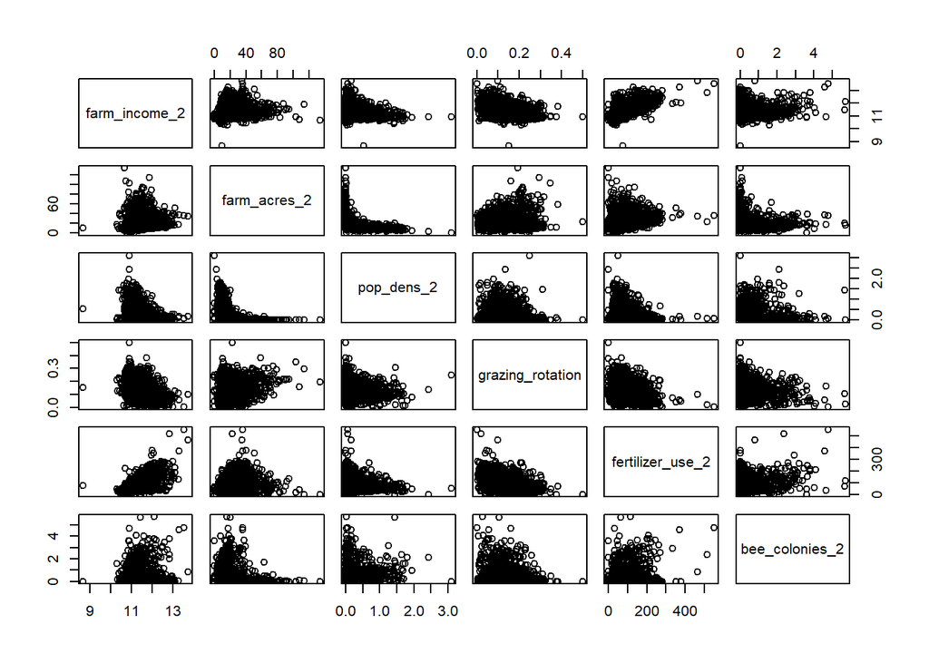

## Model comparison - nested F test

|  | Res.Df | RSS | Df | Sum of Sq | F | Pr(>F) |
| --- | --- | --- | --- | --- | --- | --- |
| 1 | 2808 | 273.55 | NA | NA | NA | NA |
| 2 | 2807 | 273.53 | 1 | 0.027553 | 0.28276 | 0.59494 |

## Final evaluation of 4 and 5 term models

fmA summary:

```
##                   Estimate Std. Error t value Pr(>|t|)
## (Intercept)      11.023637   0.024966  441.55  < 2e-16 ***
## pop_dens_2       -0.179728   0.023776   -7.56  5.5e-14 ***
## grazing_rotation -0.772752   0.116352   -6.64  3.7e-11 ***
## fertilizer_use_2  0.005092   0.000129   39.57  < 2e-16 ***
## farm_acres_2      0.001030   0.000558    1.85    0.065 .
##
## Residual standard error: 0.312 on 2808 degrees of freedom
## Multiple R-squared:  0.538,  Adjusted R-squared:  0.537
## F-statistic:  816 on 4 and 2808 DF,  p-value: <2e-16
```

fmB summary:

```
##                  Estimate Std. Error t value Pr(>|t|)
## (Intercept)      11.02278    0.02502  440.55  < 2e-16 ***
## farm_acres_2      0.00106    0.00056    1.89    0.059 .
## pop_dens_2       -0.18250    0.02434   -7.50  8.7e-14 ***
## grazing_rotation -0.77515    0.11646   -6.66  3.4e-11 ***
## fertilizer_use_2  0.00508    0.00013   39.21  < 2e-16 ***
## bee_colonies_2    0.00590    0.01109    0.53    0.595
##
## Residual standard error: 0.312 on 2807 degrees of freedom
## Multiple R-squared:  0.538,  Adjusted R-squared:  0.537
## F-statistic:  653 on 5 and 2807 DF,  p-value: <2e-16
```

## Evaluation of model without outlier, fmA3

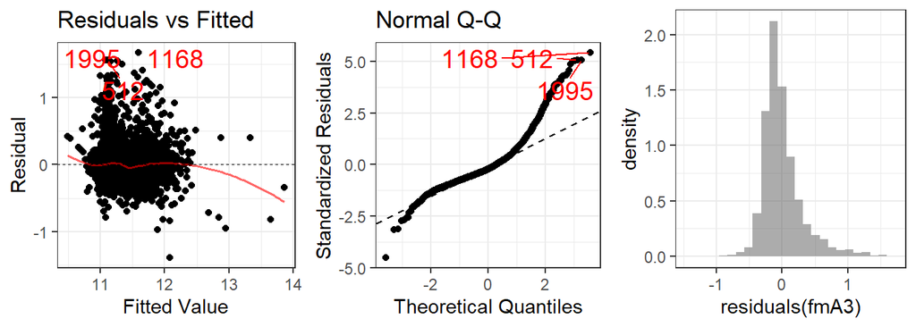

fmA3 summary:

```
##                   Estimate Std. Error t value Pr(>|t|)
## (Intercept)      11.022920   0.024677  446.68  < 2e-16 ***
## pop_dens_2       -0.175508   0.023507   -7.47  1.1e-13 ***
## grazing_rotation -0.763733   0.115014   -6.64  3.7e-11 ***
## fertilizer_use_2  0.005098   0.000127   40.07  < 2e-16 ***
## farm_acres_2      0.000991   0.000551    1.80    0.072 .
##
## Residual standard error: 0.309 on 2807 degrees of freedom
## Multiple R-squared:  0.543,  Adjusted R-squared:  0.542
## F-statistic:  833 on 4 and 2807 DF,  p-value: <2e-16
```

## Evaluation of model with interactions, fmC

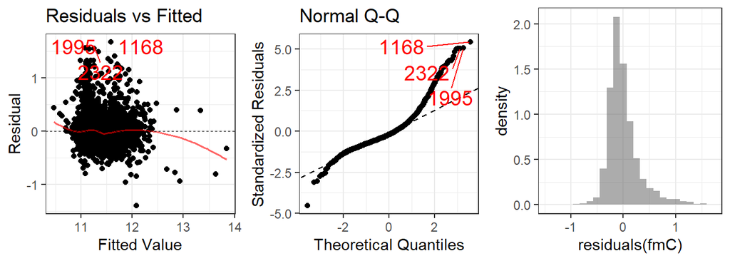

fmC summary:

```
##                              Estimate Std. Error t value Pr(>|t|)
## (Intercept)                 11.049113   0.026524  416.56  < 2e-16 ***
## pop_dens_2                  -0.249320   0.077285   -3.23   0.0013 **
## grazing_rotation            -0.888741   0.129364   -6.87  7.9e-12 ***
## fertilizer_use_2             0.004965   0.000144   34.48  < 2e-16 ***
## farm_acres_2                 0.001302   0.000561    2.32   0.0203 *
## pop_dens_2:grazing_rotation  0.729898   0.381994    1.91   0.0561 .
## pop_dens_2:fertilizer_use_2  0.001493   0.000677    2.21   0.0274 *
## pop_dens_2:farm_acres_2     -0.012375   0.005313   -2.33   0.0199 *
##
## Residual standard error: 0.308 on 2804 degrees of freedom
## Multiple R-squared:  0.544,  Adjusted R-squared:  0.543
## F-statistic:  478 on 7 and 2804 DF,  p-value: <2e-16
```

## Reverse transforming variables

```
## (Intercept)
##       61262
```

```
## pop_dens_2
##    0.30866
```

```
## grazing_rotation
##          0.46592
```

```
## fertilizer_use_2
##           1.0051
```

```
## farm_acres_2
##        1.001
```